title: “hw5_Darshana_Daga” author: “Darshana” date: “5/9/2021”

#### Question1

#### Reading data in and prepping the data

```r
options(stringsAsFactors = TRUE)
setwd('C:\\Users\\darsh\\OneDrive\\Spring Quarter\\Predictive Analytics\\Assignment 5')
options(stringsAsFactors = TRUE)    #need to run this twice
dat <- read.csv("hw5_bike_share_day.csv")

#converting data in timeseries object
cntts <- ts(dat[,14], frequency = 7)

#loading fpp2 library
library(fpp2)
#ses model
model1 <- ses(cntts, alpha = 0.25,
              initial = "simple")
summary(model1)
```

```
##
## Forecast method: Simple exponential smoothing
##
## Model Information:
## Simple exponential smoothing
##
## Call:
##  ses(y = cntts, initial = "simple", alpha = 0.25)
##
##   Smoothing parameters:
##     alpha = 0.25
##
##   Initial states:
##     l = 985
##
##   sigma:  965.0229
## Error measures:
##                    ME     RMSE      MAE       MPE     MAPE      MASE      ACF1
## Training set 6.297523 965.0229 689.1177 -49.80695 64.56823 0.7381911 0.2311695
##
## Forecasts:
##          Point Forecast    Lo 80    Hi 80      Lo 95    Hi 95
## 105.4286       2135.872 899.1459 3372.599  244.46235 4027.282
## 105.5714       2135.872 861.0839 3410.661  186.25155 4085.493
## 105.7143       2135.872 824.1258 3447.619  129.72909 4142.016
## 105.8571       2135.872 788.1809 3483.564   74.75609 4196.989
## 106.0000       2135.872 753.1701 3518.575   21.21168 4250.533
## 106.1429       2135.872 719.0241 3552.721  -31.01003 4302.755
## 106.2857       2135.872 685.6820 3586.063  -82.00247 4353.747
## 106.4286       2135.872 653.0894 3618.655 -131.84858 4403.593
## 106.5714       2135.872 621.1979 3650.547 -180.62236 4452.367
## 106.7143       2135.872 589.9642 3681.781 -228.39016 4500.135
```

```r
model1.1 <- ses(cntts)
summary(model1.1)
```

```
##
## Forecast method: Simple exponential smoothing
##
## Model Information:
## Simple exponential smoothing
##
## Call:
##  ses(y = cntts)
##
##   Smoothing parameters:
##     alpha = 0.2833
##
##   Initial states:
##     l = 1170.2635
##
##   sigma:  965.8389
##
##      AIC     AICc      BIC
## 14872.84 14872.87 14886.62
##
## Error measures:
##                    ME     RMSE      MAE       MPE     MAPE      MASE      ACF1
## Training set 4.592199 964.5168 688.6343 -49.25134 63.97796 0.7376733 0.2068816
##
## Forecasts:
##          Point Forecast    Lo 80    Hi 80      Lo 95    Hi 95
## 105.4286        2121.39 883.6178 3359.163  228.38062 4014.400
## 105.5714        2121.39 834.8934 3407.887  153.86309 4088.917
## 105.7143        2121.39 787.9482 3454.832   82.06663 4160.714
## 105.8571        2121.39 742.6005 3500.180   12.71329 4230.067
## 106.0000        2121.39 698.6975 3544.083  -54.43056 4297.211
## 106.1429        2121.39 656.1093 3586.671 -119.56354 4362.344
## 106.2857        2121.39 614.7245 3628.056 -182.85617 4425.636
## 106.4286        2121.39 574.4464 3668.334 -244.45617 4487.236
## 106.5714        2121.39 535.1908 3707.590 -304.49247 4547.273
## 106.7143        2121.39 496.8835 3745.897 -363.07843 4605.859
```

The RMSE for model 1 is 965.0229 and for model1.1 is 964.5168. Both the models are similar, but the model1.1 is slightly better as its using the starting value and alpha to optimize the outcomes.

#### Question2

```r
model2 <- holt(cntts)
summary(model2)
```

```
##
## Forecast method: Holt's method
##
## Model Information:
## Holt's method
##
## Call:
##  holt(y = cntts)
##
##   Smoothing parameters:
##     alpha = 0.2852
##     beta  = 1e-04
##
##   Initial states:
##     l = 1226.0433
##     b = 6.1773
##
##   sigma:  967.4382
##
##      AIC     AICc      BIC
## 14877.25 14877.33 14900.22
##
## Error measures:
##                     ME     RMSE      MAE       MPE     MAPE      MASE      ACF1
## Training set -18.42518 964.7877 683.9992 -50.05237 64.10281 0.7327081 0.2055892
##
## Forecasts:
##          Point Forecast    Lo 80    Hi 80      Lo 95    Hi 95
## 105.4286       2138.205 898.3830 3378.027  242.06090 4034.349
## 105.5714       2143.035 853.7349 3432.336  171.22049 4114.850
## 105.7143       2147.866 810.8839 3484.848  103.12844 4192.603
## 105.8571       2152.696 769.6440 3535.748   37.50047 4267.892
## 106.0000       2157.527 729.8594 3585.194  -25.90199 4340.955
## 106.1429       2162.357 691.3974 3633.316  -87.28148 4411.995
## 106.2857       2167.187 654.1447 3680.230 -146.81166 4481.186
## 106.4286       2172.018 618.0029 3726.032 -204.64280 4548.678
## 106.5714       2176.848 582.8864 3770.810 -260.90593 4614.602
## 106.7143       2181.678 548.7199 3814.637 -315.71614 4679.073
```

The RMSE is still similar for model1.1 964.5168 and model2 964.7877. But the ME is 4.592199 for Model1.1 and -18.42518 for model2, this shows that the error has higher degree on Model2, so I suggest Model1.1 is still better.

#### Question3

```r
model3.1 <- hw(cntts, seasonal = "additive")
model3.2 <- hw(cntts, seasonal = "multiplicative")
model3.3 <- hw(cntts, damped=TRUE, seasonal = "multiplicative")

summary(model3.1)
```

```
##
## Forecast method: Holt-Winters' additive method
##
## Model Information:
## Holt-Winters' additive method
##
## Call:
##  hw(y = cntts, seasonal = "additive")
##
##   Smoothing parameters:
##     alpha = 0.2891
##     beta  = 1e-04
##     gamma = 1e-04
##
##   Initial states:
##     l = 1284.6967
##     b = 2.5287
##     s = 170.1515 150.4275 33.2906 -5.9547 -120.9686 -174.4964
##            -52.4499
##
##   sigma:  960.3761
##
##      AIC     AICc      BIC
## 14873.46 14873.90 14928.59
##
## Error measures:
##                    ME     RMSE      MAE       MPE     MAPE      MASE      ACF1
## Training set -7.00276 953.1229 673.9503 -48.79808 62.94175 0.7219436 0.1939853
##
## Forecasts:
##          Point Forecast     Lo 80    Hi 80      Lo 95    Hi 95
## 105.4286       2175.447  944.6759 3406.219  293.14479 4057.750
## 105.5714       2216.652  935.4557 3497.848  257.23155 4176.072
## 105.7143       2335.783 1006.0400 3665.525  302.11680 4369.448
## 105.8571       2357.526  980.9159 3734.136  252.18251 4462.869
## 106.0000       2138.098  716.1331 3560.062  -36.60939 4312.805
## 106.1429       2015.609  549.6624 3481.555 -226.36263 4257.580
## 106.2857       2072.087  563.4112 3580.762 -235.23330 4379.406
## 106.4286       2189.565  639.2810 3739.849 -181.38970 4560.519
## 106.5714       2230.769  639.9648 3821.574 -202.15619 4663.695
## 106.7143       2349.900  719.5550 3980.245 -143.49754 4843.298
## 106.8571       2371.643  702.6679 4040.619 -180.83443 4924.121
## 107.0000       2152.215  445.4574 3858.973 -458.04551 4762.476
## 107.1429       2029.726  285.9796 3773.473 -637.10404 4696.556
## 107.2857       2086.204  306.2124 3866.196 -636.05815 4808.466
```

```r
summary(model3.2)
```

```
##
## Forecast method: Holt-Winters' multiplicative method
##
## Model Information:
## Holt-Winters' multiplicative method
##
## Call:
##  hw(y = cntts, seasonal = "multiplicative")
##
##   Smoothing parameters:
##     alpha = 0.2353
##     beta  = 1e-04
##     gamma = 0.0531
##
##   Initial states:
##     l = 1236.5595
##     b = 7.1759
##     s = 1.078 1.0312 0.9361 1.0534 0.9868 0.7934
##            1.1211
##
##   sigma:  0.2367
##
##      AIC     AICc      BIC
## 14896.36 14896.79 14951.49
##
## Error measures:
##                     ME     RMSE     MAE       MPE     MAPE      MASE      ACF1
## Training set -32.03015 957.2871 676.216 -49.11687 62.66111 0.7243706 0.2225966
##
## Forecasts:
##          Point Forecast    Lo 80    Hi 80     Lo 95    Hi 95
## 105.4286       2142.533 1492.527 2792.539 1148.4341 3136.631
## 105.5714       2295.791 1579.299 3012.283 1200.0117 3391.570
## 105.7143       2345.061 1593.344 3096.778 1195.4096 3494.713
## 105.8571       2409.606 1617.344 3201.868 1197.9464 3621.266
## 106.0000       2206.970 1463.606 2950.333 1070.0935 3343.846
## 106.1429       1981.594 1298.608 2664.581  937.0573 3026.132
## 106.2857       2184.388 1414.774 2954.001 1007.3650 3361.410
## 106.4286       2179.852 1387.340 2972.364  967.8089 3391.895
## 106.5714       2335.688 1469.536 3201.840 1011.0231 3660.353
## 106.7143       2385.722 1484.013 3287.431 1006.6773 3764.766
## 106.8571       2451.291 1507.664 3394.918 1008.1375 3894.444
## 107.0000       2245.062 1365.418 3124.707  899.7623 3590.363
## 107.1429       2015.719 1212.349 2819.090  787.0705 3244.369
## 107.2857       2221.920 1321.650 3122.190  845.0757 3598.764
```

```r
summary(model3.3)
```

```
##
## Forecast method: Damped Holt-Winters' multiplicative method
##
## Model Information:
## Damped Holt-Winters' multiplicative method
##
## Call:
##  hw(y = cntts, seasonal = "multiplicative", damped = TRUE)
##
##   Smoothing parameters:
##     alpha = 0.281
##     beta  = 1e-04
##     gamma = 1e-04
##     phi   = 0.9789
##
##   Initial states:
##     l = 1222.9032
##     b = 10.1823
##     s = 1.0361 1.0369 1.0123 0.9943 0.9514 0.9407
##            1.0284
##
##   sigma:  0.2358
##
##      AIC     AICc      BIC
## 14878.93 14879.44 14938.66
##
## Error measures:
##                     ME     RMSE     MAE       MPE     MAPE     MASE      ACF1
## Training set 0.8785052 944.5366 671.012 -47.27041 61.54923 0.718796 0.1991828
##
## Forecasts:
##          Point Forecast    Lo 80    Hi 80     Lo 95    Hi 95
## 105.4286       2146.096 1497.594 2794.598 1154.2980 3137.894
## 105.5714       2183.324 1496.580 2870.068 1133.0402 3233.608
## 105.7143       2235.587 1505.656 2965.519 1119.2537 3351.921
## 105.8571       2233.371 1478.236 2988.505 1078.4917 3388.249
## 106.0000       2214.736 1440.901 2988.570 1031.2577 3398.214
## 106.1429       2025.813 1295.709 2755.917  909.2157 3142.411
## 106.2857       2048.660 1288.335 2808.986  885.8426 3211.478
## 106.4286       2139.580 1323.052 2956.109  890.8074 3388.353
## 106.5714       2176.833 1323.739 3029.927  872.1386 3481.527
## 106.7143       2229.078 1333.085 3125.072  858.7749 3599.382
## 106.8571       2227.003 1309.866 3144.139  824.3632 3629.642
## 107.0000       2208.552 1277.611 3139.492  784.8008 3632.303
## 107.1429       2020.274 1149.453 2891.095  688.4680 3352.080
## 107.2857       2043.175 1143.339 2943.011  666.9949 3419.355
```

The RMSE from the three models are;

1. model3.1 (additive) is 953.1229
2. model3.2 (multiplicative) is 957.2871
3. model3.3 (multiplicative and damp = TRUE) 944.5366

The model3.3 is better among all models in question 3, as well as its better than in question 1 & 2 as well,. The reason is that the RMSE is smallest for model3.3, RMSE = 944.5366 as well as the mean error is lowest.

In HW both additive and multiplicative the fit is good as the model does simple exponential smoothing, to forecast data that has trend as well as seasonality.

The damn method of Holts accounts for the fact that its incorrect to expect a continuing upward growing trend in data by using the damp function. And that’s how the fit is best for holts-winter’s damp model.

#### Question4

```r
model4 <- hw(cntts, damped=TRUE, seasonal = "multiplicative", h=28)
summary(model4)
```

```
##
## Forecast method: Damped Holt-Winters' multiplicative method
##
## Model Information:
## Damped Holt-Winters' multiplicative method
##
## Call:
##  hw(y = cntts, h = 28, seasonal = "multiplicative", damped = TRUE)
##
##   Smoothing parameters:
##     alpha = 0.281
##     beta  = 1e-04
##     gamma = 1e-04
##     phi   = 0.9789
##
##   Initial states:
##     l = 1222.9032
##     b = 10.1823
##     s = 1.0361 1.0369 1.0123 0.9943 0.9514 0.9407
##            1.0284
##
##   sigma:  0.2358
##
##      AIC     AICc      BIC
## 14878.93 14879.44 14938.66
##
## Error measures:
##                     ME     RMSE     MAE       MPE     MAPE     MASE      ACF1
## Training set 0.8785052 944.5366 671.012 -47.27041 61.54923 0.718796 0.1991828
##
## Forecasts:
##          Point Forecast     Lo 80    Hi 80     Lo 95    Hi 95
## 105.4286       2146.096 1497.5941 2794.598 1154.2980 3137.894
## 105.5714       2183.324 1496.5804 2870.068 1133.0402 3233.608
## 105.7143       2235.587 1505.6560 2965.519 1119.2537 3351.921
## 105.8571       2233.371 1478.2359 2988.505 1078.4917 3388.249
## 106.0000       2214.736 1440.9010 2988.570 1031.2577 3398.214
## 106.1429       2025.813 1295.7093 2755.917  909.2157 3142.411
## 106.2857       2048.660 1288.3347 2808.986  885.8426 3211.478
## 106.4286       2139.580 1323.0516 2956.109  890.8074 3388.353
## 106.5714       2176.833 1323.7391 3029.927  872.1386 3481.527
## 106.7143       2229.078 1333.0851 3125.072  858.7749 3599.382
## 106.8571       2227.003 1309.8660 3144.139  824.3632 3629.642
## 107.0000       2208.552 1277.6110 3139.492  784.8008 3632.303
## 107.1429       2020.274 1149.4528 2891.095  688.4680 3352.080
## 107.2857       2043.175 1143.3392 2943.011  666.9949 3419.355
## 107.4286       2133.970 1174.4505 3093.490  666.5114 3601.429
## 107.5714       2171.243 1175.2348 3167.252  647.9796 3694.507
## 107.7143       2223.474 1183.5884 3263.359  633.1064 3813.841
## 107.8571       2221.520 1162.9190 3280.120  602.5298 3840.509
## 108.0000       2203.227 1134.1295 3272.325  568.1835 3838.271
## 108.1429       2015.504 1020.1409 3010.868  493.2272 3537.782
## 108.2857       2038.452 1014.4119 3062.491  472.3180 3604.585
## 108.4286       2129.140 1041.6236 3216.656  465.9273 3792.352
## 108.5714       2166.431 1041.8506 3291.011  446.5338 3886.328
## 108.7143       2218.648 1048.7090 3388.587  429.3808 4007.915
## 108.8571       2216.798 1029.7853 3403.811  401.4186 4032.178
## 109.0000       2198.642 1003.6281 3393.656  371.0257 4026.259
## 109.1429       2011.398  902.0977 3120.698  314.8698 3707.926
## 109.2857       2034.385  896.3172 3172.452  293.8607 3774.909
```

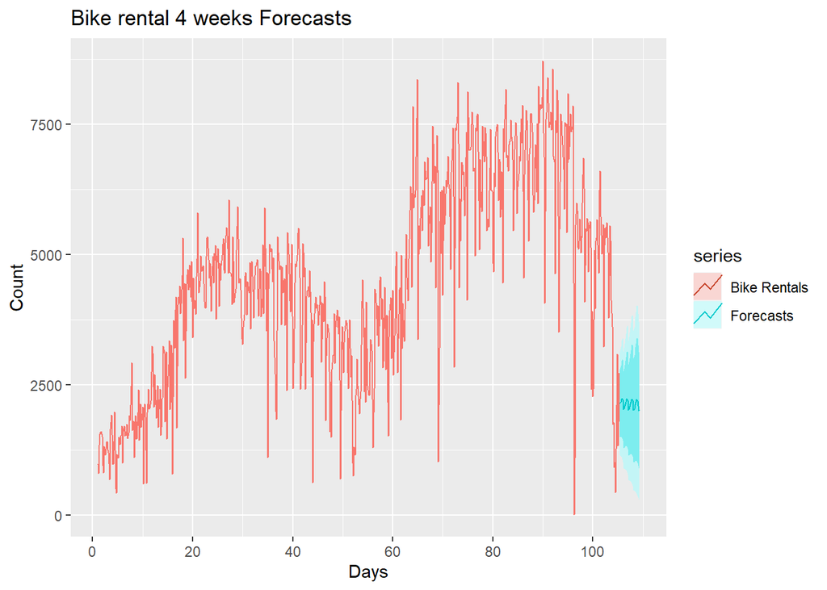

```r
autoplot(cntts, series = "Bike Rentals") +
  autolayer(model4, series = "Forecasts") +
  ggtitle("Bike rental 4 weeks Forecasts") +
  ylab("Count") +
  xlab("Days")
```

#### Question5

```r
#loading the data
fix(JohnsonJohnson)

#looking into the data
?JohnsonJohnson
```

```
## starting httpd help server ... done
```

```r
head(JohnsonJohnson)
```

```
##      Qtr1 Qtr2 Qtr3 Qtr4
## 1960 0.71 0.63 0.85 0.44
## 1961 0.61 0.69
```

```r
model5 <- ets(JohnsonJohnson, model = "AAA")
summary(model5)
```

```
## ETS(A,A,A)
##
## Call:
##  ets(y = JohnsonJohnson, model = "AAA")
##
##   Smoothing parameters:
##     alpha = 0.0701
##     beta  = 0.0699
##     gamma = 0.8563
##
##   Initial states:
##     l = 0.577
##     b = -0.0352
##     s = 0.2124 0.1273 -0.3444 0.0047
##
##   sigma:  0.4588
##
##      AIC     AICc      BIC
## 250.8828 253.3152 272.7601
##
## Training set error measures:
##                      ME      RMSE       MAE      MPE     MAPE      MASE
## Training set 0.07321067 0.4363976 0.3009786 2.398031 9.293143 0.4289736
##                   ACF1
## Training set -0.123596
```

```r
range(JohnsonJohnson)
```

```
## [1]  0.44 16.20
```

```r
coef(model5)
```

```
##       alpha        beta       gamma           l           b          s0
##  0.07005553  0.06992075  0.85627583  0.57701356 -0.03521840  0.21244342
##          s1          s2
##  0.12730488 -0.34442394
```

```r
accuracy(model5)
```

```
##                      ME      RMSE       MAE      MPE     MAPE      MASE
## Training set 0.07321067 0.4363976 0.3009786 2.398031 9.293143 0.4289736
##                   ACF1
## Training set -0.123596
```

```r
fitted(model5)
```

```
##            Qtr1       Qtr2       Qtr3       Qtr4
## 1960  0.5464708  0.1850430  0.6952710  0.8093953
## 1961  0.7080932  0.5785605  0.8028321  0.4488273
## 1962  0.6290003  0.7215536  0.9713340  0.6050633
## 1963  0.7748898  0.8317889  0.9881962  0.6680710
## 1964  0.9065010  0.8927488  1.1126192  0.9022393
## 1965  1.0888418  1.1876233  1.4536642  1.2281531
## 1966  1.4007626  1.5192789  1.6500175  1.4579471
## 1967  1.4991739  1.6452160  2.1010202  1.7693157
## 1968  1.7344417  1.7595615  2.0509961  2.1022027
## 1969  1.8565733  2.4316150  2.7344789  2.6711382
## 1970  2.5081592  2.8082254  3.1565452  2.8722399
## 1971  3.5423589  4.2442241  4.5854446  4.4532050
## 1972  4.4328631  5.1645534  5.1739653  4.9165731
## 1973  5.5763614  5.7527428  5.7319024  5.2537887
## 1974  6.4594705  6.7249757  7.3172989  6.0072285
## 1975  6.6905556  7.0390823  7.6868495  6.6757102
## 1976  7.7076872  8.4592732  8.6168386  6.9450227
## 1977  8.5149619  9.7666629  9.3281109  8.0068728
## 1978 10.7740152 11.7533071 11.2248351 10.6053520
## 1979 13.5758217 13.8257850 13.6628244 10.7541986
## 1980 15.6405485 14.7665266 16.4773003 11.7295152
```

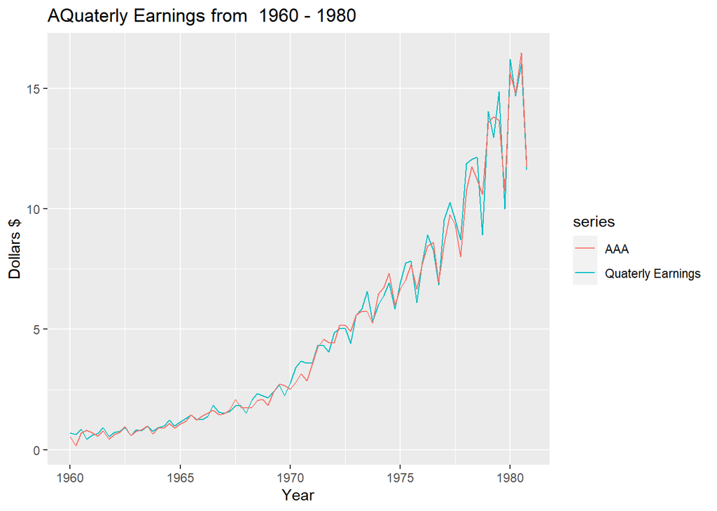

```r
autoplot(JohnsonJohnson, series = "Quaterly Earnings") +
  autolayer(fitted(model5), series = "AAA") +
  ggtitle("AQuaterly Earnings from  1960 - 1980") +
  ylab("Dollars $") +
  xlab("Year")
```

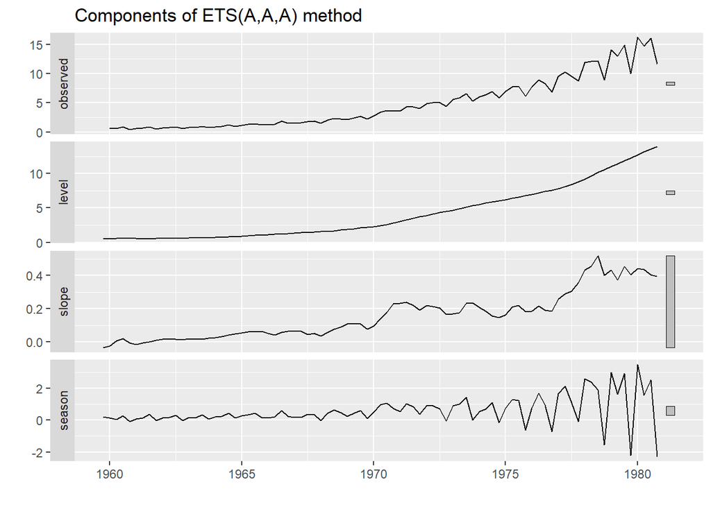

```r
autoplot(model5)
```

The data is of quarterly earning in dollars per share of Johnson & Johnson share from 1960 to 1980. There are 84 observation in the data, ranging from year 1960 to 1980, across 4 quarters. The range of values is from 0.44 to 16.20 dollar earning per share. The model components & fit is as below; Call: ets(y = JohnsonJohnson, model = “AAA”)

Smoothing parameters: alpha = 0.0701 beta = 0.0699 gamma = 0.8563

Initial states: l = 0.577 b = -0.0352 s = 0.2124 0.1273 -0.3444 0.0047

sigma: 0.4588

[output not shown]

250.8828 253.3152 272.7601

#### Question6

```r
model6.1 <- ets(JohnsonJohnson, model = "ANN")
summary(model6.1)
```

```
## ETS(A,N,N)
##
## Call:
##  ets(y = JohnsonJohnson, model = "ANN")
##
##   Smoothing parameters:
##     alpha = 0.4234
##
##   Initial states:
##     l = 0.6862
##
##   sigma:  1.1734
##
##      AIC     AICc      BIC
## 403.0264 403.3264 410.3188
##
## Training set error measures:
##                     ME     RMSE       MAE      MPE     MAPE     MASE      ACF1
## Training set 0.3611078 1.159332 0.7294681 5.849539 14.66732 1.039684 -0.299932
```

```r
model6.2 <- ets(JohnsonJohnson, model = "AAN")
summary(model6.2)
```

```
## ETS(A,A,N)
##
## Call:
##  ets(y = JohnsonJohnson, model = "AAN")
##
##   Smoothing parameters:
##     alpha = 0.0906
##     beta  = 0.0906
##
##   Initial states:
##     l = 0.7007
##     b = -0.0077
##
##   sigma:  1.0062
##
##      AIC     AICc      BIC
## 379.1267 379.8959 391.2808
##
## Training set error measures:
##                      ME      RMSE       MAE       MPE     MAPE      MASE
## Training set 0.01711501 0.9819394 0.5428696 0.1161491 11.68062 0.7737318
##                    ACF1
## Training set -0.3044142
```

```r
model6.3 <- ets(JohnsonJohnson, model = "MAA", damped = TRUE)
summary(model6.3)
```

```
## ETS(M,Ad,A)
##
## Call:
##  ets(y = JohnsonJohnson, model = "MAA", damped = TRUE)
##
##   Smoothing parameters:
##     alpha = 0.2142
##     beta  = 0.0587
##     gamma = 0.6771
##     phi   = 0.98
##
##   Initial states:
##     l = 0.6284
##     b = 0.0198
##     s = -0.2453 0.2402 -0.0274 0.0326
##
##   sigma:  0.0967
##
##      AIC     AICc      BIC
## 171.2899 174.3036 195.5981
##
## Training set error measures:
##                     ME      RMSE       MAE      MPE     MAPE      MASE
## Training set 0.1123243 0.4620244 0.2913338 2.263957 6.773863 0.4152272
##                    ACF1
## Training set -0.2937956
```

```r
model6.4 <- ets(JohnsonJohnson, model = "MAM", damped = TRUE)
summary(model6.4)
```

```
## ETS(M,Ad,M)
##
## Call:
##  ets(y = JohnsonJohnson, model = "MAM", damped = TRUE)
##
##   Smoothing parameters:
##     alpha = 0.1131
##     beta  = 0.1131
##     gamma = 0.0484
##     phi   = 0.98
##
##   Initial states:
##     l = 0.6122
##     b = 0.0041
##     s = 0.8698 1.1283 1.0064 0.9955
##
##   sigma:  0.1138
##
##      AIC     AICc      BIC
## 200.2331 203.2468 224.5413
##
## Training set error measures:
##                      ME      RMSE       MAE      MPE     MAPE      MASE
## Training set 0.04674649 0.6459112 0.3867718 1.109937 8.369819 0.5512515
##                    ACF1
## Training set -0.1731452
```

```r
RMSE_ets <- data.frame(matrix(0,4,1))
RMSE_ets[1,1] <- summary(model6.1)[,2]
```

```
## ETS(A,N,N)
##
## Call:
##  ets(y = JohnsonJohnson, model = "ANN")
##
##   Smoothing parameters:
##     alpha = 0.4234
##
##   Initial states:
##     l = 0.6862
##
##   sigma:  1.1734
##
##      AIC     AICc      BIC
## 403.0264 403.3264 410.3188
##
## Training set error measures:
##                     ME     RMSE       MAE      MPE     MAPE     MASE      ACF1
## Training set 0.3611078 1.159332 0.7294681 5.849539 14.66732 1.039684 -0.299932
```

```r
RMSE_ets[2,1] <- summary(model6.2)[,2]
```

```
## ETS(A,A,N)
##
## Call:
##  ets(y = JohnsonJohnson, model = "AAN")
##
##   Smoothing parameters:
##     alpha = 0.0906
##     beta  = 0.0906
##
##   Initial states:
##     l = 0.7007
##     b = -0.0077
##
##   sigma:  1.0062
##
##      AIC     AICc      BIC
## 379.1267 379.8959 391.2808
##
## Training set error measures:
##                      ME      RMSE       MAE       MPE     MAPE      MASE
## Training set 0.01711501 0.9819394 0.5428696 0.1161491 11.68062 0.7737318
##                    ACF1
## Training set -0.3044142
```

```r
RMSE_ets[3,1] <- summary(model6.3)[,2]
```

```
## ETS(M,Ad,A)
##
## Call:
##  ets(y = JohnsonJohnson, model = "MAA", damped = TRUE)
##
##   Smoothing parameters:
##     alpha = 0.2142
##     beta  = 0.0587
##     gamma = 0.6771
##     phi   = 0.98
##
##   Initial states:
##     l = 0.6284
##     b = 0.0198
##     s = -0.2453 0.2402 -0.0274 0.0326
##
##   sigma:  0.0967
##
##      AIC     AICc      BIC
## 171.2899 174.3036 195.5981
##
## Training set error measures:
##                     ME      RMSE       MAE      MPE     MAPE      MASE
## Training set 0.1123243 0.4620244 0.2913338 2.263957 6.773863 0.4152272
##                    ACF1
## Training set -0.2937956
```

```r
RMSE_ets[4,1] <- summary(model6.4)[,2]
```

```
## ETS(M,Ad,M)
##
## Call:
##  ets(y = JohnsonJohnson, model = "MAM", damped = TRUE)
##
##   Smoothing parameters:
##     alpha = 0.1131
##     beta  = 0.1131
##     gamma = 0.0484
##     phi   = 0.98
##
##   Initial states:
##     l = 0.6122
##     b = 0.0041
##     s = 0.8698 1.1283 1.0064 0.9955
##
##   sigma:  0.1138
##
##      AIC     AICc      BIC
## 200.2331 203.2468 224.5413
##
## Training set error measures:
##                      ME      RMSE       MAE      MPE     MAPE      MASE
## Training set 0.04674649 0.6459112 0.3867718 1.109937 8.369819 0.5512515
##                    ACF1
## Training set -0.1731452
```

```r
names(RMSE_ets) <- "MSE"
rownames(RMSE_ets) <- c("ANN", "AAN", "MAA-Damped", "MAM-Damped")

RMSE_ets
```

```
##                  MSE
## ANN        1.1593317
## AAN        0.9819394
## MAA-Damped 0.4620244
## MAM-Damped 0.6459112
```

Comparing all the AIC (both in question 6 & Question 5), the lowest AIC is for ets model “MAA” with AIC of 171.2899.

#### Question7

The ets() function by default estimates the maximum likelihood of data than providing the minimum sum of squares for errors. The ets() function is not trying to forecast, instead it just is trying to use the model which has the optimal value for the ets parameters and returns information about the fitted model.

A important factor is ets() function takes into account error due to the multiplicative function which can come in if there are zero or negative numbers in the data.

So even though the AAA mode had a lower RMSE, we still looked at AIC as that is the parameter to test how large is the likelihood of the data coming out of the ets model. As the AIC of MAA is much smaller compared at 171.2899 to AIC for AAA model at 250.8828.

#### Question8

```r
fix(debitcards)

model8.1 <- ets(debitcards)
model8.2 <- ets(debitcards, model = "ANN")
model8.3 <- ets(debitcards, model = "AAN")
model8.4 <- ets(debitcards, model = "AAA")
model8.5 <- ets(debitcards, model = "MAA", damped = TRUE)
model8.6 <- ets(debitcards, model = "MAM", damped = TRUE)

RMSE_ets8 <- data.frame(matrix(0,6,1))
RMSE_ets8[1,1] <- summary(model8.1)[,2]
```

```
## ETS(M,A,M)
##
## Call:
##  ets(y = debitcards)
##
##   Smoothing parameters:
##     alpha = 0.3831
##     beta  = 1e-04
##     gamma = 5e-04
##
##   Initial states:
##     l = 8.2195
##     b = 0.0813
##     s = 1.2572 0.9576 0.9868 0.9771 1.1039 1.0637
##            1.0374 1.0278 0.9198 0.9231 0.8602 0.8854
##
##   sigma:  0.0469
##
##      AIC     AICc      BIC
## 738.9388 743.1305 791.6365
##
## Training set error measures:
##                      ME      RMSE       MAE         MPE     MAPE      MASE
## Training set 0.01998494 0.7239404 0.5423039 -0.01069241 3.456976 0.4232463
##                    ACF1
## Training set -0.1427266
```

```r
RMSE_ets8[2,1] <- summary(model8.2)[,2]
```

```
## ETS(A,N,N)
##
## Call:
##  ets(y = debitcards, model = "ANN")
##
##   Smoothing parameters:
##     alpha = 0.2028
##
##   Initial states:
##     l = 8.07
##
##   sigma:  2.0455
##
##     AIC    AICc     BIC
## 1075.09 1075.24 1084.39
##
## Training set error measures:
##                     ME     RMSE      MAE      MPE     MAPE     MASE
## Training set 0.4496368 2.032951 1.563872 1.833719 9.568447 1.220539
##                      ACF1
## Training set -0.006799714
```

```r
RMSE_ets8[3,1] <- summary(model8.3)[,2]
```

```
## ETS(A,A,N)
##
## Call:
##  ets(y = debitcards, model = "AAN")
##
##   Smoothing parameters:
##     alpha = 0.0208
##     beta  = 0.0208
##
##   Initial states:
##     l = 7.5446
##     b = 0.2061
##
##   sigma:  1.9831
##
##      AIC     AICc      BIC
## 1066.896 1067.275 1082.395
##
## Training set error measures:
##                       ME     RMSE      MAE       MPE     MAPE     MASE
## Training set -0.03296228 1.958757 1.517056 -1.531555 9.521443 1.184001
##                   ACF1
## Training set 0.1179531
```

```r
RMSE_ets8[4,1] <- summary(model8.4)[,2]
```

```
## ETS(A,A,A)
##
## Call:
##  ets(y = debitcards, model = "AAA")
##
##   Smoothing parameters:
##     alpha = 0.2621
##     beta  = 1e-04
##     gamma = 0.3926
##
##   Initial states:
##     l = 8.2406
##     b = 0.0847
##     s = 3.0423 -0.0944 -0.018 -0.427 1.0605 0.4779
##            0.0115 0.5457 -1.0726 -0.6045 -1.5508 -1.3706
##
##   sigma:  0.8592
##
##      AIC     AICc      BIC
## 803.7638 807.9556 856.4616
##
## Training set error measures:
##                       ME      RMSE       MAE        MPE     MAPE      MASE
## Training set 0.007956851 0.8162029 0.6223727 -0.1755408 3.932436 0.4857368
##                     ACF1
## Training set -0.05486448
```

```r
RMSE_ets8[5,1] <- summary(model8.5)[,2]
```

```
## ETS(M,Ad,A)
##
## Call:
##  ets(y = debitcards, model = "MAA", damped = TRUE)
##
##   Smoothing parameters:
##     alpha = 0.2759
##     beta  = 0.0402
##     gamma = 0.3101
##     phi   = 0.9694
##
##   Initial states:
##     l = 8.7111
##     b = -0.0466
##     s = 3.3327 -0.5671 -0.4959 -0.4533 1.1049 0.5297
##            0.3108 0.3368 -0.6998 -0.6652 -1.4803 -1.2534
##
##   sigma:  0.0546
##
##      AIC     AICc      BIC
## 788.6234 793.3407 844.4210
##
## Training set error measures:
##                      ME      RMSE       MAE       MPE     MAPE      MASE
## Training set 0.06671147 0.8430113 0.6459475 0.2831751 4.092748 0.5041361
##                     ACF1
## Training set -0.03754854
```

```r
RMSE_ets8[6,1] <- summary(model8.6)[,2]
```

```
## ETS(M,Ad,M)
##
## Call:
##  ets(y = debitcards, model = "MAM", damped = TRUE)
##
##   Smoothing parameters:
##     alpha = 0.3383
##     beta  = 0.0198
##     gamma = 1e-04
##     phi   = 0.98
##
##   Initial states:
##     l = 8.2985
##     b = 0.0815
##     s = 1.2493 0.9524 0.9842 0.9685 1.1106 1.0687
##            1.0383 1.0329 0.918 0.9229 0.8632 0.8909
##
##   sigma:  0.0477
##
##      AIC     AICc      BIC
## 744.4223 749.1395 800.2199
##
## Training set error measures:
##                      ME      RMSE       MAE       MPE     MAPE      MASE
## Training set 0.06516411 0.7267452 0.5498696 0.2892121 3.513916 0.4291511
##                     ACF1
## Training set -0.09844187
```

```r
names(RMSE_ets8) <- "MSE"
rownames(RMSE_ets8) <- c('Optimal', 'ANN', 'AAN', 'AAA', 'MAA-Damped', 'MAM-Damped')

RMSE_ets8
```

```
##                  MSE
## Optimal    0.7239404
## ANN        2.0329511
## AAN        1.9587566
## AAA        0.8162029
## MAA-Damped 0.8430113
## MAM-Damped 0.7267452
```

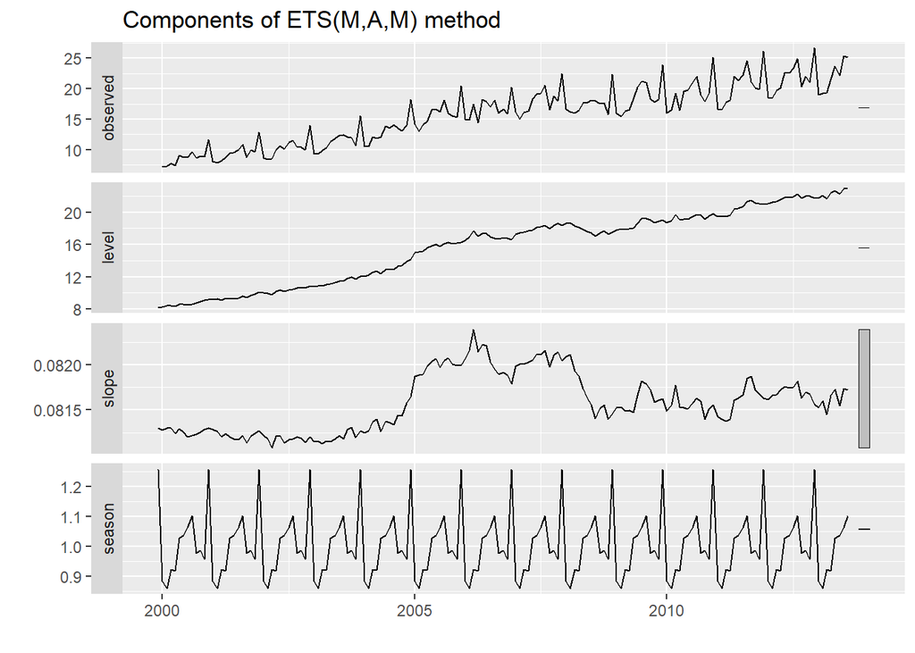

```r
autoplot(model8.1 )
```

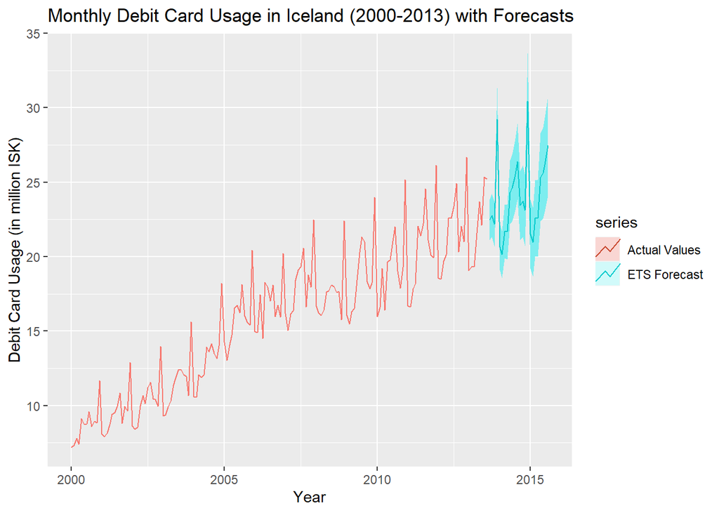

```r
model8  <- forecast(model8.1 , h = 24, level = 80)

autoplot(debitcards, series = "Actual Values") +
  autolayer(model8, series = 'ETS Forecast') +
  ggtitle("Monthly Debit Card Usage in Iceland (2000-2013) with Forecasts") +
  ylab("Debit Card Usage (in million ISK)") +
  xlab("Year")
```

The model choosen by optimal ets is MAM. The associated parameters for the model are as below;

> ETS(M,A,M) Call: ets(y = debitcards) Smoothing parameters: alpha = 0.3831 beta = 0.0001 gamma = 0.0005 Initial states: l = 8.2195 b = 0.0813 s = 1.2572 0.9576 0.9868 0.9771 1.1039 1.0637 1.0374 1.0278 0.9198 0.9231 0.8602 0.8854 sigma: 0.0469 AIC AICc BIC 738.9388 743.1305 791.6365 Training set error measures: ME RMSE MAE MPE MAPE Training set 0.01998494 0.7239404 0.5423039 -0.01069241 3.456976 MASE ACF1 Training set 0.4232463 -0.1427266

#### Question9

```r
#fix(goog)
model9.1 <- ets(goog)

RMSE9 <- data.frame(matrix(0,1,1))
RMSE9[1,1] <- summary(model9.1)[,2]
```

```
## ETS(M,N,N)
##
## Call:
##  ets(y = goog)
##
##   Smoothing parameters:
##     alpha = 0.9999
##
##   Initial states:
##     l = 392.7798
##
##   sigma:  0.0147
##
##      AIC     AICc      BIC
## 11220.52 11220.55 11235.25
##
## Training set error measures:
##                     ME     RMSE      MAE        MPE     MAPE      MASE
## Training set 0.4209327 8.729954 5.823624 0.06249646 0.973181 0.9990079
##                    ACF1
## Training set 0.03881924
```

```r
names(RMSE9) <- "RMSE"
row.names(RMSE9) <- 'Optimal'
RMSE9
```

```
##             RMSE
## Optimal 8.729954
```

```r
summary(model9.1)
```

```
## ETS(M,N,N)
##
## Call:
##  ets(y = goog)
##
##   Smoothing parameters:
##     alpha = 0.9999
##
##   Initial states:
##     l = 392.7798
##
##   sigma:  0.0147
##
##      AIC     AICc      BIC
## 11220.52 11220.55 11235.25
##
## Training set error measures:
##                     ME     RMSE      MAE        MPE     MAPE      MASE
## Training set 0.4209327 8.729954 5.823624 0.06249646 0.973181 0.9990079
##                    ACF1
## Training set 0.03881924
```

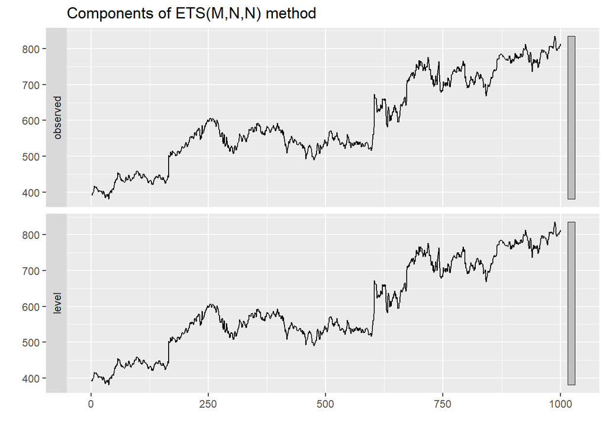

```r
autoplot(model9.1)
```

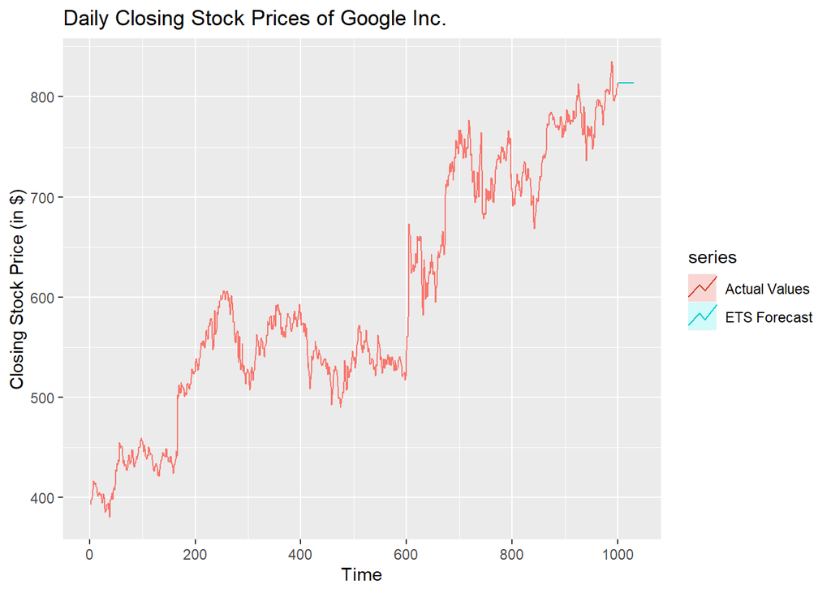

```r
gofcst <- forecast(model9.1, h = 30, level = FALSE)

autoplot(goog, series = "Actual Values") +
  autolayer(gofcst, series = 'ETS Forecast') +
  ggtitle("Daily Closing Stock Prices of Google Inc.") +
  ylab("Closing Stock Price (in $)") +
  xlab("Time")
```

The best model selected by ETS is (M,N,N).The associated parameters for the model are as below;

> ETS(M,N,N) Call: ets(y = goog) Smoothing parameters: alpha = 0.9999 Initial states: l = 392.7798 sigma: 0.0147 AIC AICc BIC 11220.52 11220.55 11235.25 Training set error measures: ME RMSE MAE MPE MAPE MASE Training set 0.4209327 8.729954 5.823624 0.06249646 0.973181 0.9990079 ACF1 Training set 0.03881924 ETS(M,N,N)

#### Question10

```r
Model10 <- auto.arima(goog)

summary(Model10)
```

```
## Series: goog
## ARIMA(0,1,0) with drift
##
## Coefficients:
##        drift
##       0.4213
## s.e.  0.2760
##
## sigma^2 estimated as 76.19:  log likelihood=-3581.45
## AIC=7166.89   AICc=7166.9   BIC=7176.7
##
## Training set error measures:
##                        ME     RMSE      MAE         MPE      MAPE     MASE
## Training set 0.0003924086 8.719767 5.831708 -0.01050304 0.9753774 1.000395
##                    ACF1
## Training set 0.03871058
```

```r
accuracy(Model10)
```

```
##                        ME     RMSE      MAE         MPE      MAPE     MASE
## Training set 0.0003924086 8.719767 5.831708 -0.01050304 0.9753774 1.000395
##                    ACF1
## Training set 0.03871058
```

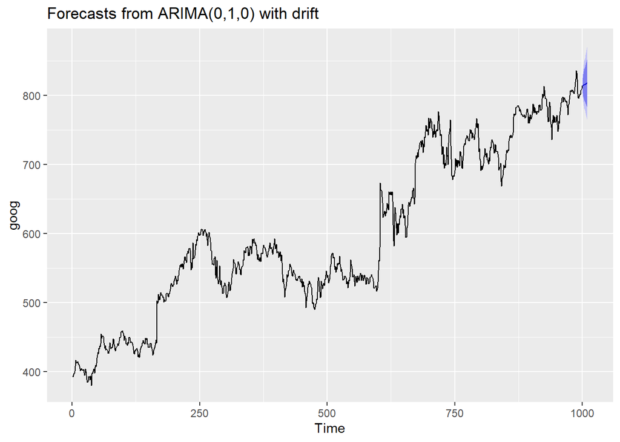

```r
autoplot(forecast(Model10))
```

The auto Arima model selected the ARIMA(0,1,0) with drift . In my opinion the auto Arima model is better than the model9 as model9 has an AIC of 11220.52 whereas the Arima model has an AIC of 7166.89. Much lower compared ETS(M,N,N) model in Question9. Arima tries to minimize the AICc and MLE and give model with the smallest AICc value. The model RMSE is 8.7197.